# 2D Incompressible RANS SIMPLE Finite-Volume Solver with $k$–$\varepsilon$

[figure not shown]

### Project Overview

This repository contains a custom Python/NumPy finite-volume solver for 2D incompressible RANS flows using SIMPLE pressure–velocity coupling. The code is structured around a segregated solution framework for momentum, pressure correction, and scalar transport, with a standard $k$–$\varepsilon$ turbulence model and wall-function treatment for near-wall regions.

This codebase is a stepping stone toward other canonical 2D cases (e.g. cylinder, backward-facing step) and toward generating labelled simulation data for a follow-on project using GNNs and related surrogates.

### Numerical Formulation

- **Governing equations:** Incompressible RANS with eddy viscosity $\nu_t = C_\mu \frac{k^2}{\varepsilon}$
- **Algorithm:** SIMPLE-based pressure–velocity coupling
  - Momentum solve → pressure correction → velocity/flux correction
  - Rhie–Chow interpolation applied to prevent pressure–velocity decoupling
- **Discretisation:**
  - FVM on a structured 2D mesh (cell-centred variables)
  - Gradients Scheme: Green–Gauss reconstruction
  - Convection Discretisation Scheme: linear-upwind (with optional higher-order/deferred correction)
  - Diffusion Discretisation Scheme: central differencing

[figure not shown]

Click flowchart to expand

### Turbulence Modelling

- **Model:** Standard $k$–$\varepsilon$ (two-equation)
- **Transport equations:** Solved in segregated form

### Wall Treatment

- **Approach:** High-Re wall functions
  - $y^+$-based piecewise switching between viscous sublayer and log-law
  - Near-wall adjustments to $\nu_t$, $\varepsilon$, and production $P_k$
- **Alternative:** Low-Re (fully resolved) formulation retained for future extension

### Linear Solvers

# PYTHON CODE

```python
import numpy as np
import matplotlib.pyplot as plt
# Sparse matrix solver
import scipy.sparse as sp
import scipy.sparse.linalg as spla
# Algebraic Multigrid
import pyamg
```

# Helper function

```python
#
def build_csr_vectorized(aP, aL, aR, aB, aT):
    ny, nx = aP.shape

    # Flatten the arrays
    d_P = aP.flatten()
    d_L = -aL.flatten()[1:]    # Offset -1
    d_R = -aR.flatten()[:-1]   # Offset +1
    d_B = -aB.flatten()[nx:]   # Offset -nx
    d_T = -aT.flatten()[:-nx]  # Offset +nx

    # Build sparse matrix instantly using diagonals
    A = sp.diags([d_B, d_L, d_P, d_R, d_T],
                 offsets=[-nx, -1, 0, 1, nx],
                 format='csr')
    return A

def build_csr_from_5pt(aP, aL, aR, aB, aT):
    ny, nx = aP.shape
    N = ny * nx
    rows, cols, data = [], [], []

    def idx(j, i):
        return j * nx + i

    for j in range(ny):
        for i in range(nx):
            p = idx(j, i)

            # diagonal
            rows.append(p); cols.append(p); data.append(aP[j, i])

            # neighbors (matrix uses -a_nb in your formulation)
            if i > 0:
                rows.append(p); cols.append(idx(j, i-1)); data.append(-aL[j, i])
            if i < nx - 1:
                rows.append(p); cols.append(idx(j, i+1)); data.append(-aR[j, i])
            if j > 0:
                rows.append(p); cols.append(idx(j-1, i)); data.append(-aB[j, i])
            if j < ny - 1:
                rows.append(p); cols.append(idx(j+1, i)); data.append(-aT[j, i])

    A = sp.csr_matrix((data, (rows, cols)), shape=(N, N))
    return A

def solve_bicgstab_ilu(aP, aL, aR, aB, aT, S, phi0=None,
                       rtol=1e-8, atol=1e-12, maxiter=500):
    ny, nx = aP.shape
    # A = build_csr_from_5pt(aP, aL, aR, aB, aT)
    A = build_csr_vectorized(aP, aL, aR, aB, aT)
    b = S.reshape(-1)

    # ILU preconditioner (built from CSC)
    A_csc = A.tocsc()
    ilu = spla.spilu(A_csc, drop_tol=1e-4, fill_factor=10)
    M = spla.LinearOperator(A.shape, matvec=ilu.solve)

    x0 = None if phi0 is None else phi0.reshape(-1)

    # x, info = spla.bicgstab(A, b, x0=x0, M=M, rtol=rtol, atol=atol, maxiter=maxiter)
    x, info = spla.bicgstab(A, b, x0=x0, rtol=rtol, atol=atol, maxiter=maxiter)

    if info != 0:
        # info>0: no convergence in maxiter, info<0: breakdown
        raise RuntimeError(f"BiCGStab failed, info={info}")

    return x.reshape(ny, nx)
```

```python
def solve_pressure_amg(aP_p, aL_p, aR_p, aB_p, aT_p, b_p, p0=None,
                       rtol=1e-10, maxiter=300):
    # A = build_csr_from_5pt(aP_p, aL_p, aR_p, aB_p, aT_p)
    A = build_csr_vectorized(aP_p, aL_p, aR_p, aB_p, aT_p)
    b = b_p.reshape(-1)

    ml = pyamg.smoothed_aggregation_solver(A)     # AMG hierarchy
    M = ml.aspreconditioner(cycle='V')            # preconditioner for Krylov

    x0 = None if p0 is None else p0.reshape(-1)

    # If matrix is SPD use CG; otherwise use BiCGStab
    x, info = spla.cg(A, b, x0=x0, M=M, rtol=rtol, atol=1e-14, maxiter=maxiter)
    # x, info = spla.bicgstab(A, b, x0=x0, M=M, rtol=rtol, atol=1e-14, maxiter=maxiter)

    if info != 0:
        raise RuntimeError(f"Pressure solve failed, info={info}")

    return x.reshape(aP_p.shape)
```

# Memory Allocation

```python
### Cell-center fields (shape: `ny × nx`)

### Geometry (pre-computed once)
# Define number of cells
nx = 200
ny = 10

# Define Domain size
lx = 20.0
ly = 1.0

xx = np.linspace(lx/nx/2, lx - lx/nx/2, nx)
yy = np.linspace(ly/ny/2, ly - ly/ny/2, ny)
xcc, ycc = np.meshgrid(xx, yy)

# Velocity
u       =   np.zeros((ny, nx)) # current velocity components
v       =   np.zeros((ny, nx)) # current velocity components

u_old   =   np.zeros((ny, nx)) # previous iteration (for under-relaxation source)
v_old   =   np.zeros((ny, nx)) # previous iteration (for under-relaxation source)

# Pressure
p       =   np.zeros((ny, nx)) # pressure (kinematic, p/ρ)
p_old   =   np.zeros((ny, nx)) # previous iteration (for under-relaxation source)

# Turbulence
k       =   np.zeros((ny, nx)) # turbulent kinetic energy
epsilon =   np.zeros((ny, nx)) # dissipation
k_old   =   np.zeros((ny, nx)) # previous iteration
eps_old =   np.zeros((ny, nx)) # previous iteration
nu_t    =   np.zeros((ny, nx)) # eddy viscosity = C_mu * k² / epsilon
nu_eff  =   np.zeros((ny, nx)) # effective viscosity = nu + nu_t

# Momentum matrix storage (needed for H/A construction)
aP_u    =   np.zeros((ny, nx)) # diagonal coefficients (raw, not divided by V)
aP_v    =   np.zeros((ny, nx)) # diagonal coefficients (raw, not divided by V)
H_x     =   np.zeros((ny, nx)) # H operator for x- and y-momentum
H_y     =   np.zeros((ny, nx)) # H operator for x- and y-momentum

# Neighbor coefficients (for iterative solver + H construction)
aR_u    =   np.zeros((ny, nx)) # u-momentum neighbor coefficients
aT_u    =   np.zeros((ny, nx)) # u-momentum neighbor coefficients
aL_u    =   np.zeros((ny, nx)) # u-momentum neighbor coefficients
aB_u    =   np.zeros((ny, nx)) # u-momentum neighbor coefficients
aR_v    =   np.zeros((ny, nx)) # v-momentum neighbor coefficients
aT_v    =   np.zeros((ny, nx)) # v-momentum neighbor coefficients
aL_v    =   np.zeros((ny, nx)) # v-momentum neighbor coefficients
aB_v    =   np.zeros((ny, nx)) # v-momentum neighbor coefficients
S_u     =   np.zeros((ny, nx)) # explicit source terms for momentum
S_v     =   np.zeros((ny, nx)) # explicit source terms for momentum

# Pressure matrix storage (needed for H/A construction)
aP_p    =   np.zeros((ny, nx)) # diagonal coefficients (raw, not divided by V)

# Neighbor coefficients (for iterative solver + H construction)
aR_p    =   np.zeros((ny, nx)) # u-momentum neighbor coefficients
aT_p    =   np.zeros((ny, nx)) # u-momentum neighbor coefficients
aL_p    =   np.zeros((ny, nx)) # u-momentum neighbor coefficients
aB_p    =   np.zeros((ny, nx)) # u-momentum neighbor coefficients
S_p     =   np.zeros((ny, nx)) # explicit source terms for momentum

# turbulent kinetic energy matrix storage
aP_k    =   np.zeros((ny, nx)) # diagonal coefficients (raw, not divided by V)

# Neighbor coefficients (for iterative solver + H construction)
aR_k    =   np.zeros((ny, nx)) # u-momentum neighbor coefficients
aT_k    =   np.zeros((ny, nx)) # u-momentum neighbor coefficients
aL_k    =   np.zeros((ny, nx)) # u-momentum neighbor coefficients
aB_k    =   np.zeros((ny, nx)) # u-momentum neighbor coefficients
S_k     =   np.zeros((ny, nx)) # explicit source terms for momentum

# turbulent kinetic energy dissipation matrix storage
aP_eps    =   np.zeros((ny, nx)) # diagonal coefficients (raw, not divided by V)

# Neighbor coefficients (for iterative solver + H construction)
aR_eps    =   np.zeros((ny, nx)) # u-momentum neighbor coefficients
aT_eps    =   np.zeros((ny, nx)) # u-momentum neighbor coefficients
aL_eps    =   np.zeros((ny, nx)) # u-momentum neighbor coefficients
aB_eps    =   np.zeros((ny, nx)) # u-momentum neighbor coefficients
S_eps     =   np.zeros((ny, nx)) # explicit source terms for momentum

# Cell-center gradients
dudx    =   np.zeros((ny, nx)) # ∇u
dudy    =   np.zeros((ny, nx)) # ∇u
dvdx    =   np.zeros((ny, nx)) # ∇v
dvdy    =   np.zeros((ny, nx)) # ∇v
dpdx    =   np.zeros((ny, nx)) # ∇p  (needed for Rhie-Chow)
dkdx    =   np.zeros((ny, nx)) # ∇k
depsdx  =   np.zeros((ny, nx)) # ∇ε

### Face fields

# Face mass flux — shared by ALL transport equations
phi_x   =   np.zeros((ny, nx-1))       # flux through x-faces (vertical faces)
phi_y   =   np.zeros((ny-1, nx))       # flux through y-faces (horizontal faces)

# phiHbyA (pressure-free flux, used as RHS of pressure equation)
phiHbyA_x   =   np.zeros((ny, nx-1))
phiHbyA_y   =   np.zeros((ny-1, nx))

# Face effective viscosity
nu_eff_xf   =   np.zeros((ny, nx+1))   # interpolated to x-faces
nu_eff_yf   =   np.zeros((ny+1, nx))   # interpolated to y-faces


# Define mesh spacing
dx      =   np.full((ny, nx), lx/nx)                # cell widths
dy      =   np.full((ny, nx), ly/ny)                # cell heights
vol     =   dx*dy                 # cell volumes = dx * dy
Sf_x    =   np.full((ny, nx+1), dy[0,0])               # x-face areas = dy
Sf_y    =   np.full((ny+1, nx), dx[0,0])               # y-face areas = dx
dist_x  =   np.full((ny, nx-1), dx[0,0])             # center-to-center distance across x-faces
dist_y  =   np.full((ny-1, nx), dy[0,0])             # center-to-center distance across y-faces
r_x     =   np.full((ny, nx), dx[0,0]/2)             # distance from cell center to face center across x-faces
r_y     =   np.full((ny, nx), dy[0,0]/2)             # distance from cell center to face center across y-faces

# Define linear interpolation weights
wx      =   np.full((ny, nx-1), (dx[:,1:]/2)/dist_x)             # linear interpolation weights
wy      =   np.full((ny-1, nx), (dy[1:,:]/2)/dist_y)             # linear interpolation weights
```

# Step 0: Initialisation

```python
# Set all cell-center fields to initial/boundary values:
U_in = 10
u      =   np.full((ny, nx), U_in) # initial velocity np.full((ny, nx), U_in)
v      =   np.zeros((ny, nx)) # initial velocity
p      =   np.zeros((ny, nx)) # initial guess

U_ref = 10      # reference velocity
I = 0.05        # turbulence intensity
C_mu = 0.09     # Cmu constant
l_mix = 0.1     # mixing length, 10% channel diameter
nu = 1.5e-5     # kinematic viscosity
k_in = 1.5 * (U_ref * I)**2 # inlet turbulent kinetic energy 1.5 * (U_ref * I)²
k      =   np.full((ny, nx), k_in) # initial guess turbulent kinetic energy  - k_in

epsilon_in = C_mu**0.75 * k_in**1.5 / l_mix # inlet dissipation C_mu^0.75 * k^1.5 / l_mix
epsilon =   np.full((ny, nx), epsilon_in) # initial guess dissipation C_mu^0.75 * k^1.5 / l_mix

nu_t    =   C_mu * k**2 / epsilon # eddy viscosity C_mu * k² / epsilon
nu_eff  =   nu + nu_t # effective viscosity nu + nu_t

# # Compute initial face fluxes (needed for first convection assembly):
# linear interp to get face values
u_xf = wx * u[:, 1:] + (1-wx) * u[:, :-1]        # linear interpolation
u_yf = wy * u[1:, :] + (1-wy) * u[:-1, :]        # linear interpolation
v_xf = wx * v[:, 1:] + (1-wx) * v[:, :-1]        # linear interpolation
v_yf = wy * v[1:, :] + (1-wy) * v[:-1, :]        # linear interpolation

# apply boundary conditions
u_xf_BC_L = np.full((ny,1), U_in) # velocity inlet at left wall
u_xf_BC_R = u[:, -1:]             # zero gradient: face value = cell value
u_yf_BC_B = np.full((1,nx), 0)    # no slip at bottom wall
u_yf_BC_T = np.full((1,nx), 0)    # no slip at top wall

v_xf_BC_L = np.full((ny,1), 0) # no vertical velocity at left wall
v_xf_BC_R = v[:, -1:]          # zero gradient: face value = cell value
v_yf_BC_B = np.full((1,nx), 0) # no slip at bottom wall
v_yf_BC_T = np.full((1,nx), 0) # no slip at top wall

u_xf = np.hstack((u_xf_BC_L, u_xf, u_xf_BC_R))
u_yf = np.vstack((u_yf_BC_B, u_yf, u_yf_BC_T))
v_xf = np.hstack((v_xf_BC_L, v_xf, v_xf_BC_R))
v_yf = np.vstack((v_yf_BC_B, v_yf, v_yf_BC_T))

# compute face fluxes for the first iteration convection term
phi_x = u_xf * Sf_x
phi_y = v_yf * Sf_y
```

# BEGIN OUTER SIMPLE ITERATION

```python
phi_tol = 4e-4
u_tol = 1e-6
v_tol = 1e-6
p_tol = 1e-6
k_tol = 1e-6
eps_tol = 1e-9

R_phi = 1e10
R_u = 1e10
R_v = 1e10
R_p = 1e10
R_k = 1e10
R_eps = 1e10

iter = 0

while iter < 1 and (R_phi > phi_tol or R_u > u_tol or R_v > v_tol or R_p > p_tol or R_k > k_tol or R_eps > eps_tol):
    iter += 1
```

# Step 1: Update turbulent viscosity

```python
# ==========================================
# STEP 1: TURBULENT VISCOSITY
# ==========================================

# 1. Update Interior Turbulent Viscosity
nu_t = C_mu * k**2 / np.maximum(epsilon, 1e-10)
# nu_t = np.clip(nu_t, 0.0, 10000 * nu)
nu_eff = nu + nu_t

# 2. Interpolate to faces (Interior & Inlets/Outlets as you currently do)
nu_eff_xf = wx * nu_eff[:, 1:] + (1-wx) * nu_eff[:, :-1]
nu_eff_yf = wy * nu_eff[1:, :] + (1-wy) * nu_eff[:-1, :]

# Left BC face and Right BC face
nu_eff_xf_BC_L = np.full((ny, 1), nu + C_mu * k_in**2 / epsilon_in)
nu_eff_xf_BC_R = nu_eff[:, -1:]

nu_eff_xf = np.hstack((nu_eff_xf_BC_L, nu_eff_xf, nu_eff_xf_BC_R))
```

Top and Bottom BC Velocity wall function (modifying $\nu_{t}$)

Using the y* approach (instead of y+) $$u_{\tau}=C_{\mu}^{1/4} \sqrt{k_P} \leftarrow y* approach$$ $$u_{\tau}= \sqrt{\frac{\tau_w}{\rho}} \leftarrow y^+ approach $$

for y+ < 11.25 (viscous sub-layer): $$\nu_t = 0$$

for y+ > 11.25 (log-law region): $$\nu_t = \nu \left( \frac{y^+}{\frac{1}{\kappa} log(E y^+)} -1 \right)$$

```python
kappa = 0.41
E = 9.81
y_cutoff = 11.225
y_P_B = dist_y[0, 0] / 2.0  # y Distance to bottom cell center
y_P_T = dist_y[-1, 0] / 2.0 # y Distance to top cell center

# 3. Calculate Wall Friction Scales (u* (or u_tau) and y*)
k_P_B = np.maximum(k[0, :], 1e-10)
k_P_T = np.maximum(k[-1, :], 1e-10)

u_star_B = (C_mu**0.25) * np.sqrt(k_P_B)
u_star_T = (C_mu**0.25) * np.sqrt(k_P_T)

y_star_B = (y_P_B * u_star_B) / nu
y_star_T = (y_P_T * u_star_T) / nu

# 4. Overwrite Top and Bottom Wall Faces with Piece-Wise Wall Function
nu_eff_B = np.where(y_star_B > y_cutoff, nu * kappa * y_star_B / np.log(E * y_star_B), nu)
nu_eff_T = np.where(y_star_T > y_cutoff, nu * kappa * y_star_T / np.log(E * y_star_T), nu)

nu_eff_yf_BC_B = nu_eff_B.reshape(1, nx)
nu_eff_yf_BC_T = nu_eff_T.reshape(1, nx)

nu_eff_yf = np.vstack((nu_eff_yf_BC_B, nu_eff_yf, nu_eff_yf_BC_T))
```

# Step 2: Compute cell-center gradients

To get: dudx, dudy, dvdx, dvdy, dpdx, dpdy,

(dkdx, dkdy, depsdx, depsdy no longer used, as k and epsilon convective terms cannot use linear-upwind scheme due to un-physical undershoot )

```python
# Step 2a: linear interp to get face values
u_xf = wx * u[:, 1:] + (1-wx) * u[:, :-1]
u_yf = wy * u[1:, :] + (1-wy) * u[:-1, :]
v_xf = wx * v[:, 1:] + (1-wx) * v[:, :-1]
v_yf = wy * v[1:, :] + (1-wy) * v[:-1, :]

# Step 2b: apply boundary conditions
# U_in = 10
u_xf_BC_L = np.full((ny,1), U_in) # velocity inlet at left wall
u_xf_BC_R = u[:, -1:]             # zero gradient: face value = cell value
u_yf_BC_B = np.full((1,nx), 0)    # no slip at bottom wall
u_yf_BC_T = np.full((1,nx), 0)    # no slip at top wall

v_xf_BC_L = np.full((ny,1), 0) # no vertical velocity at left wall
v_xf_BC_R = v[:, -1:]          # zero gradient: face value = cell value
v_yf_BC_B = np.full((1,nx), 0) # no slip at bottom wall
v_yf_BC_T = np.full((1,nx), 0) # no slip at top wall

u_xf = np.hstack((u_xf_BC_L, u_xf, u_xf_BC_R))
u_yf = np.vstack((u_yf_BC_B, u_yf, u_yf_BC_T))
v_xf = np.hstack((v_xf_BC_L, v_xf, v_xf_BC_R))
v_yf = np.vstack((v_yf_BC_B, v_yf, v_yf_BC_T))

# Step 2c: compute gradients using Green-Gauss theorem
dudx = (1/vol) * (u_xf[:,1:]*Sf_x[:,1:] - u_xf[:,:-1]*Sf_x[:,:-1]) # Right face - Left face
dudy = (1/vol) * (u_yf[1:,:]*Sf_y[1:,:] - u_yf[:-1,:]*Sf_y[:-1,:]) # Top face - Bottom face

dvdx = (1/vol) * (v_xf[:,1:]*Sf_x[:,1:] - v_xf[:,:-1]*Sf_x[:,:-1]) # Right face - Left face
dvdy = (1/vol) * (v_yf[1:,:]*Sf_y[1:,:] - v_yf[:-1,:]*Sf_y[:-1,:]) # Top face - Bottom face
```

```python
# Step 2a: linear interp to get face values
p_xf = wx * p[:, 1:] + (1-wx) * p[:, :-1]
p_yf = wy * p[1:, :] + (1-wy) * p[:-1, :]


# Step 2b: apply boundary conditions
p_out = 0
p_xBC_L = p[:, :1]                            # zero gradient inlet at left wall
p_xBC_R = np.full((ny, 1), p_out)             # fixed outlet pressure
p_yBC_T = p[-1:, :]                           # zero gradient at top wall
p_yBC_B = p[:1, :]                            # zero gradient at bottom wall

p_xf = np.hstack((p_xBC_L, p_xf, p_xBC_R))
p_yf = np.vstack((p_yBC_B, p_yf, p_yBC_T))

# Step 2c: compute gradients using Green-Gauss theorem
dpdx = (1/vol) * (p_xf[:,1:]*Sf_x[:,1:] - p_xf[:,:-1]*Sf_x[:,:-1]) # Right face - Left face
dpdy = (1/vol) * (p_yf[1:,:]*Sf_y[1:,:] - p_yf[:-1,:]*Sf_y[:-1,:]) # Top face - Bottom face
```

# Step 3: Assemble U-MOMENTUM matrix

Step 3a: initialise

```python
aP_u[:,:] = 0
aR_u[:,:] = 0;  aT_u[:,:] = 0;  aL_u[:,:] = 0;  aB_u[:,:] = 0
S_u[:,:] = 0
```

Step 3b: convection $$ \sum_{i=1}^M U_{fi}F_{fi}$$

```python
# linear upwind differencing scheme

# interior faces
# # implicit part
# x-faces (interior only: phi_x[:, 1:-1])
F_xf = phi_x[:, 1:-1]  # shape (ny, nx-1)
# # # L face
aP_u[:, 1:]  += np.maximum(-F_xf, 0)
aL_u[:, 1:]  += np.maximum(F_xf, 0)
# # # R face
aP_u[:, :-1] += np.maximum(F_xf, 0)
aR_u[:, :-1] += np.maximum(-F_xf, 0)
# y-faces (interior only: phi_y[1:-1, :])
F_yf = phi_y[1:-1, :]  # shape (ny-1, nx)
# # # B face
aP_u[1:, :]  += np.maximum(-F_yf, 0)
aB_u[1:, :]  += np.maximum(F_yf, 0)
# # # T face
aP_u[:-1, :] += np.maximum(F_yf, 0)
aT_u[:-1, :] += np.maximum(-F_yf, 0)

# # explicit part
# For each x-face, determine upstream gradient and distance
# If F > 0: upstream = left cell, r_to_face = +r_x (positive)
# If F < 0: upstream = right cell, r_to_face = -r_x (negative)
# Correction: delta_u = dudx_upstream * r_to_face
# Source contributions:
#   S_left  -= delta_u * F   (right face of left cell)
#   S_right += delta_u * F   (left face of right cell)

# # # L face
# phi_x are face values with cell number +1.
# dudx are cell center values.
# r_x are distance from cell center to face center. (since this r array is used for both left and right, hence the sign to account for the direction,)
S_u[:,1:] +=  np.maximum(F_xf, 0) * dudx[:, :-1] * r_x[:, :-1]
S_u[:,1:] +=  np.maximum(-F_xf, 0) * dudx[:, 1:] * r_x[:, 1:]
# # # R face
S_u[:,:-1] += -np.maximum(F_xf, 0) * dudx[:, :-1] * r_x[:, :-1]
S_u[:,:-1] += -np.maximum(-F_xf, 0) * dudx[:, 1:] * r_x[:, 1:]
# # # B face
S_u[1:,:] +=  np.maximum(F_yf, 0) * dudy[:-1, :] * r_y[:-1, :]
S_u[1:,:] +=  np.maximum(-F_yf, 0) * dudy[1:, :] * r_y[1:, :]
# # # T face
S_u[:-1,:] += -np.maximum(F_yf, 0) * dudy[:-1, :] * r_y[:-1, :]
S_u[:-1,:] += -np.maximum(-F_yf, 0) * dudy[1:, :] * r_y[1:, :]


# Boundary faces
# left boundary (velocity inlet)
F_left = phi_x[:, 0]
# known face value at velocity inlet (accounting for backflow)
S_u[:,0] += np.maximum(F_left, 0) * u_xf[:,0]
aP_u[:,0] += np.maximum(-F_left, 0) # incase backflow

# right boundary (zero gradient)
F_right = phi_x[:, -1]
#  zero gradient: u_face = u_cell, so gradient term = 0
aP_u[:, -1] += np.maximum(F_right, 0) # outflux if F > 0
aP_u[:, -1] += np.maximum(-F_right, 0) # infux if F < 0

# # top boundary (no slip condition)

# # bottom boundary (no slip condition)
```

Step 3c: diffusion implicit $$ \sum_{i=1}^M v_{eff_{fi}} \left( \nabla{U} \right)_{fi} \cdot \hat{n_i} A_{i} $$ $$ \sum_{i=1}^M v_{eff_{fi}} \left( \frac{U_P-U_N}{|d_{PN}|} |\Delta_{fi}|\right) A_{i} $$ For cartesian grid: $$ = U_{P}\sum_{i=1}^M v_{eff_{fi}} \left( \frac{A_{i}}{|d_{PN}|} \right) - \sum_{i=1}^M U_{N} v_{eff_{fi}} \left( \frac{A_{i}}{|d_{PN}|} \right)$$

```python
# interior cell
# x faces
D_xf = nu_eff_xf[:, 1:-1] * Sf_x[:, 1:-1]/dist_x
# L face
aP_u[:,1:] += D_xf # +ve LHS term
aL_u[:,1:] += D_xf # +ve after moved to RHS
# R face
aP_u[:,:-1] += D_xf # +ve LHS term
aR_u[:,:-1] += D_xf # +ve after moved to RHS

# y faces
D_yf = nu_eff_yf[1:-1, :] * Sf_y[1:-1, :]/dist_y
# B face
aP_u[1:,:] += D_yf # +ve LHS term
aB_u[1:,:] += D_yf # +ve after moved to RHS
# T face
aP_u[:-1,:] += D_yf # +ve LHS term
aT_u[:-1,:] += D_yf # +ve after moved to RHS

# boundary cell (treating the boundary face as a cell)
# left face
D_xf_BC_L = nu_eff_xf[:,0] * Sf_x[:,0]/(dist_x[0,0]/2) # special case, distance is half of the cell width, can generalise into dist_x/2
aP_u[:,0] += D_xf_BC_L # +ve LHS term
S_u[:,0] += U_in * D_xf_BC_L # +ve after moved to RHS
# right face
#  zero gradient: u_face = u_cell, so diffusion flux UP = UN --> (nothing to add)
# bottom face
D_yf_BC_B = nu_eff_yf[0,:] * Sf_y[0,:]/(dist_y[0,0]/2)
aP_u[0,:] += D_yf_BC_B # +ve LHS term
S_u[0,:] += 0 # no slip velocity at bottom wall, therefore no source term
# top face
D_yf_BC_T = nu_eff_yf[-1,:] * Sf_y[-1,:]/(dist_y[0,0]/2)
aP_u[-1,:] += D_yf_BC_T # +ve LHS term
S_u[-1,:] += 0 # no slip velocity at top wall, therefore no source term
```

step 3d: diffusion Boussinesq $$ \sum_{i=1}^M v_{eff_{fi}} \left( \nabla{U} \right)_{fi}^{T} \cdot \hat{n_i} A_{i} $$

```python
dudx_xf = wx * dudx[:, 1:] + (1-wx) * dudx[:, :-1] # <-- x - momentum

dvdx_yf = wy * dvdx[1:, :] + (1-wy) * dvdx[:-1, :] # <-- x - momentum


# !left wall - linear interpolation, right wall - zero gradient, bottom, top wall = 0 from no slip
dudx_xf_BC_L = (u[:, :1] - U_in) / (dx[:, :1] / 2)   # (u_cell - u_face) / distance, treating inlet face as a cell to direct differecing
dudx_xf_BC_R = dudx[:,-1:] # zero gradient outlet

dvdx_yf_BC_B = np.zeros((1, nx))   # v = 0 along bottom wall → ∂v/∂x = 0
dvdx_yf_BC_T = np.zeros((1, nx))   # v = 0 along top wall    → ∂v/∂x = 0


dudx_xf = np.hstack((dudx_xf_BC_L, dudx_xf, dudx_xf_BC_R))

dvdx_yf = np.vstack((dvdx_yf_BC_B, dvdx_yf, dvdx_yf_BC_T))

# interior cell
# # x faces
cross_xf = nu_eff_xf[:, 1:-1] * dudx_xf[:, 1:-1] * Sf_x[:, 1:-1]
# L face
S_u[:,1:] += -cross_xf # +ve after moved to RHS
# R face
S_u[:,:-1] += cross_xf # -ve after moved to RHS

# # y faces
cross_yf = nu_eff_yf[1:-1,:] * dvdx_yf[1:-1,:] * Sf_y[1:-1,:]
# B face
S_u[1:,:] += -cross_yf # +ve after moved to RHS
# T face
S_u[:-1,:] += cross_yf # -ve after moved to RHS

# boundary cell
# left face
cross_xf_BC_L = nu_eff_xf[:,0] * dudx_xf[:,0] * Sf_x[:,0]
S_u[:,0] += -cross_xf_BC_L # outward = -x, so subtract
# right face
cross_xf_BC_R = nu_eff_xf[:, -1] * dudx_xf[:, -1] * Sf_x[:, -1]
S_u[:, -1] += cross_xf_BC_R # outward = +x, so add

# # top face v = 0 everywhere along wall → ∂v/∂x = 0 → no contribution

# # bottom face v = 0 everywhere along wall → ∂v/∂x = 0 → no contribution
```

step 3e: Pressure $$ \sum_{i=1}^M p^{*}_{fi} \hat{n_i} A_{i}$$

```python
# flipped sign as RHS=-∇p
p_xf_L = p_xf[:,:-1] * Sf_x[:,:-1]
p_xf_R = p_xf[:,1:] * Sf_x[:,1:]

# L faces
S_u[:,:] += p_xf_L
# R faces
S_u[:,:] += -p_xf_R
```

step 3f: Under-relaxation $$a_{P}\phi_{P}^n + \frac{1-\alpha}{\alpha}a_{P}\phi_{P}^n + \sum_{i=1}^{M}a_{N}\phi_{N}^n = S_{P} + \frac{1-\alpha}{\alpha}a_{P}\phi_{P}^n$$ $$\frac{a_{P}}{\alpha}\phi_{P}^n + \sum_{i=1}^{M}a_{N}\phi_{N}^n = S_{P} + \frac{1-\alpha}{\alpha}a_{P}\phi_{P}^n$$

```python
alpha_u = 0.5       # under-relaxation factor
u_old = u.copy()

S_u += (1-alpha_u)/alpha_u * aP_u * u_old # under-relaxation source
aP_u = aP_u/alpha_u # inflate diagonal
```

# Step 4: Solving U and extract H

step 4a: Gauss-Siedel $$U_{p}=\frac{1}{A_P} \left( H - \nabla{p} \right)$$ or $$U_{p}^{*}=\frac{1}{A_P} \left( \sum_{nb} A_{nb} U_{nb} + S_{p} \right)$$ Result: u* (intermediate x-velocity)

```python
# # # Option 1: Gauss-Siedel (Very slow, require alternating directions)
# n_inner_iter = 5000

# # # Gauss-Siedel iterate cell by cell using previously updated cell values.
# # # Jocobi precomputes the all neighbour values and update the cell value, hencing using the old cell value.
# for iter in range(n_inner_iter):
#     for i in range(nx):
#         # j_range = range(ny) if iter % 2 == 0 else range(ny - 1, -1, -1)
#         for j in range(ny):
#             u_L = u[j, i-1] if i > 0 else 0.0 # no neighbouring cell on the left
#             u_R = u[j, i+1] if i < nx-1 else 0.0 # no neighbouring cell on the right
#             u_T = u[j+1, i] if j < ny-1 else 0.0 # no neighbouring cell on the top
#             u_B = u[j-1, i] if j > 0 else 0.0 # no neighbouring cell on the bottom

#             u[j, i] = 1/aP_u[j, i] * (aL_u[j, i]*u_L + aR_u[j, i]*u_R + aT_u[j, i]*u_T + aB_u[j, i]*u_B + S_u[j, i])


# # # Option 2: numpy Linear matrix equation (slow)
# N = ny * nx
# A_u = np.zeros((N, N))
# b_u = np.zeros(N)
# for j in range(ny):
#     for i in range(nx):
#         idx = j * nx + i
#         A_u[idx, idx] = aP_u[j, i]
#         b_u[idx] = S_u[j, i]
#         if i > 0:     A_u[idx, idx - 1]  = -aL_u[j, i]
#         if i < nx - 1: A_u[idx, idx + 1]  = -aR_u[j, i]
#         if j < ny - 1: A_u[idx, idx + nx] = -aT_u[j, i]
#         if j > 0:      A_u[idx, idx - nx] = -aB_u[j, i]
# u = np.linalg.solve(A_u, b_u).reshape((ny, nx))
```

```python
# # # Option 3: Biconjugate gradient stabilised + ILU preconditioner
u = solve_bicgstab_ilu(aP_u, aL_u, aR_u, aB_u, aT_u, S_u, phi0=u)
```

step 4b: extract H_x $$H = A_{P} u^{*} + \nabla p$$ notice this H includes other source terms, therefore we have to recompute the pressure terms from $S_{p}$ (after FVM discretisations) $$H = A_{P} u^{*} + \nabla p \cdot V$$ $$H = A_{P} u^{*} + \sum_{i=1}^M p^{*}_{fi} \hat{n_i} A_{i}$$

```python
grad_p_x_vol = p_xf_R - p_xf_L # p_xf computed from the velocity predictor pressure step 3e
H_x = aP_u * u + grad_p_x_vol
```

step 4c compute HbyA_x

```python
HbyA_x = H_x/aP_u # cell-center, shape (ny,nx)
```

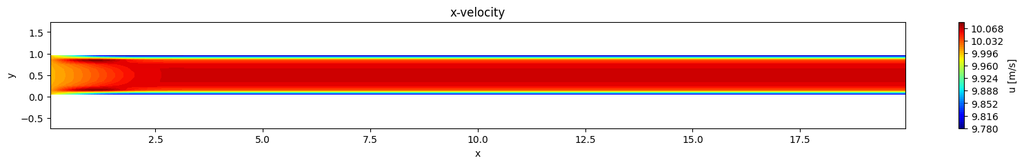

```python
# Check Plots
plt.figure(figsize=(20, 2))
cf = plt.contourf(xcc, ycc, u, levels=50, cmap='jet')
plt.colorbar(cf, label='u [m/s]')
plt.xlabel('x'); plt.ylabel('y')
plt.title('x-velocity')
plt.axis('equal')
plt.show()
```

# Step 5: Assemble V-MOMENTUM matrix

Step 5a: initialise

```python
aP_v[:,:] = 0
aR_v[:,:] = 0;  aT_v[:,:] = 0;  aL_v[:,:] = 0;  aB_v[:,:] = 0
S_v[:,:] = 0
```

Step 5b: convection $$ \sum_{i=1}^M U_{fi}F_{fi}$$

```python
# linear upwind differencing scheme

# interior faces
# # implicit part
# x-faces (interior only: phi_x[:, 1:-1])
F_xf = phi_x[:, 1:-1]  # shape (ny, nx-1)
# # # L face
aP_v[:, 1:]  += np.maximum(-F_xf, 0)
aL_v[:, 1:]  += np.maximum(F_xf, 0)
# # # R face
aP_v[:, :-1] += np.maximum(F_xf, 0)
aR_v[:, :-1] += np.maximum(-F_xf, 0)
# y-faces (interior only: phi_y[1:-1, :])
F_yf = phi_y[1:-1, :]  # shape (ny-1, nx)
# # # B face
aP_v[1:, :]  += np.maximum(-F_yf, 0)
aB_v[1:, :]  += np.maximum(F_yf, 0)
# # # T face
aP_v[:-1, :] += np.maximum(F_yf, 0)
aT_v[:-1, :] += np.maximum(-F_yf, 0)

# # explicit part
# For each x-face, determine upstream gradient and distance
# If F > 0: upstream = left cell, r_to_face = +r_x (positive)
# If F < 0: upstream = right cell, r_to_face = -r_x (negative)
# Correction: delta_u = dudx_upstream * r_to_face
# Source contributions:
#   S_left  -= delta_u * F   (right face of left cell)
#   S_right += delta_u * F   (left face of right cell)

# # # L face
# phi_x are face values with cell number +1.
# dudx are cell center values.
# r_x are distance from cell center to face center. (since this r array is used for both left and right, hence the sign to account for the direction,)
S_v[:,1:] +=  np.maximum(F_xf, 0) * dvdx[:, :-1] * r_x[:, :-1]
S_v[:,1:] +=  np.maximum(-F_xf, 0) * dvdx[:, 1:] * r_x[:, 1:]
# # # R face
S_v[:,:-1] += -np.maximum(F_xf, 0) * dvdx[:, :-1] * r_x[:, :-1]
S_v[:,:-1] += -np.maximum(-F_xf, 0) * dvdx[:, 1:] * r_x[:, 1:]
# # # B face
S_v[1:,:] += np.maximum(F_yf, 0) * dvdy[:-1, :] * r_y[:-1, :]
S_v[1:,:] += np.maximum(-F_yf, 0) * dvdy[1:, :] * r_y[1:, :]
# # # T face
S_v[:-1,:] += -np.maximum(F_yf, 0) * dvdy[:-1, :] * r_y[:-1, :]
S_v[:-1,:] += -np.maximum(-F_yf, 0) * dvdy[1:, :] * r_y[1:, :]

# Boundary faces

# # left boundary (velocity inlet) (0 in y-direction)

# right boundary (zero gradient)
F_right = phi_x[:, -1]
#  zero gradient: u_face = u_cell, so gradient term = 0
aP_v[:, -1] += np.maximum(F_right, 0) # outflux if F > 0
aP_v[:, -1] += np.maximum(-F_right, 0) # infux if F < 0

# # top boundary (no slip condition)

# # bottom boundary (no slip condition)
```

Step 5c: diffusion implicit $$ \sum_{i=1}^M v_{eff_{fi}} \left( \nabla{U} \right)_{fi} \cdot \hat{n_i} A_{i} $$ $$ \sum_{i=1}^M v_{eff_{fi}} \left( \frac{U_P-U_N}{|d_{PN}|} |\Delta_{fi}|\right) A_{i} $$ For cartesian grid: $$ = U_{P}\sum_{i=1}^M v_{eff_{fi}} \left( \frac{A_{i}}{|d_{PN}|} \right) - \sum_{i=1}^M U_{N} v_{eff_{fi}} \left( \frac{A_{i}}{|d_{PN}|} \right)$$

```python
# interior cell
# x faces
D_xf = nu_eff_xf[:, 1:-1] * Sf_x[:, 1:-1]/dist_x
# L face
aP_v[:,1:] += D_xf # +ve LHS term
aL_v[:,1:] += D_xf # +ve after moved to RHS
# R face
aP_v[:,:-1] += D_xf # +ve LHS term
aR_v[:,:-1] += D_xf # +ve after moved to RHS

# y faces
D_yf = nu_eff_yf[1:-1, :] * Sf_y[1:-1, :]/dist_y
# B face
aP_v[1:,:] += D_yf # +ve LHS term
aB_v[1:,:] += D_yf # +ve after moved to RHS
# T face
aP_v[:-1,:] += D_yf # +ve LHS term
aT_v[:-1,:] += D_yf # +ve after moved to RHS

# boundary cell (treating the boundary face as a cell)
# left face
D_xf_BC_L = nu_eff_xf[:,0] * Sf_x[:,0]/(dist_x[0,0]/2) # special case, distance is half of the cell width, can generalise into dist_x/2
aP_v[:,0] += D_xf_BC_L # +ve LHS term
S_v[:,0] += 0 * D_xf_BC_L # +ve after moved to RHS
# right face
#  zero gradient: u_face = u_cell, so diffusion flux UP = UN --> (nothing to add)
# bottom face
D_yf_BC_B = nu_eff_yf[0,:] * Sf_y[0,:]/(dist_y[0,0]/2)
aP_v[0,:] += D_yf_BC_B # +ve LHS term
S_v[0,:] += 0 # no slip velocity at bottom wall, therefore no source term
# top face
D_yf_BC_T = nu_eff_yf[-1,:] * Sf_y[-1,:]/(dist_y[0,0]/2)
aP_v[-1,:] += D_yf_BC_T # +ve LHS term
S_v[-1,:] += 0 # no slip velocity at top wall, therefore no source term
```

step 5d: diffusion Boussinesq $$ \sum_{i=1}^M v_{eff_{fi}} \left( \nabla{U} \right)_{fi}^{T} \cdot \hat{n_i} A_{i} $$

```python
dudy_xf = wx * dudy[:, 1:] + (1-wx) * dudy[:, :-1] # <-- y - momentum

dvdy_yf = wy * dvdy[1:, :] + (1-wy) * dvdy[:-1, :] # <-- y - momentum

# left wall - linear interpolation, right wall - zero gradient, bottom, top wall = 0 from no slip
dudy_xf_BC_L =  np.zeros((ny, 1))   # uniform inlet
dudy_xf_BC_R = dudy[:,-1:] # zero gradient outlet

dvdy_yf_BC_B = np.zeros((1, nx)) # continuity equation
dvdy_yf_BC_T = np.zeros((1, nx)) # continuity equation


dudy_xf = np.hstack((dudy_xf_BC_L, dudy_xf, dudy_xf_BC_R))

dvdy_yf = np.vstack((dvdy_yf_BC_B, dvdy_yf, dvdy_yf_BC_T))

# interior cell
# # x faces
cross_xf = nu_eff_xf[:, 1:-1] * dudy_xf[:, 1:-1] * Sf_x[:, 1:-1]
# L face
S_v[:,1:] += -cross_xf # +ve after moved to RHS
# R face
S_v[:,:-1] += cross_xf # -ve after moved to RHS

# # y faces
cross_yf = nu_eff_yf[1:-1,:] * dvdy_yf[1:-1,:] * Sf_y[1:-1,:]
# B face
S_v[1:,:] += -cross_yf # +ve after moved to RHS
# T face
S_v[:-1,:] += cross_yf # -ve after moved to RHS

# boundary cell
# left face # for completeness (uniform inlet, dudy = 0)

# right face
cross_xf_BC_R = nu_eff_xf[:, -1] * dudy_xf[:, -1] * Sf_x[:, -1]
S_v[:, -1] += cross_xf_BC_R # outward = +x, so add

# # top face u = 0 everywhere along wall, continuity equation ∂u/∂x + ∂v/∂y = 0

# # bottom face u = 0 everywhere along wall, continuity equation ∂u/∂x + ∂v/∂y = 0
```

step 5e: Pressure $$ \sum_{i=1}^M p^{*}_{fi} \hat{n_i} A_{i}$$

```python
# flipped sign as RHS=-∇p
p_yf_T = p_yf[1:,:] * Sf_y[1:,:]
p_yf_B = p_yf[:-1,:] * Sf_y[:-1,:]

# T face
S_v[:,:] += -p_yf_T
# B face
S_v[:,:] += p_yf_B
```

step 5f: Under-relaxation $$a_{P}\phi_{P}^n + \frac{1-\alpha}{\alpha}a_{P}\phi_{P}^n + \sum_{i=1}^{M}a_{N}\phi_{N}^n = S_{P} + \frac{1-\alpha}{\alpha}a_{P}\phi_{P}^n$$ $$\frac{a_{P}}{\alpha}\phi_{P}^n + \sum_{i=1}^{M}a_{N}\phi_{N}^n = S_{P} + \frac{1-\alpha}{\alpha}a_{P}\phi_{P}^n$$

```python
alpha_v = 0.5       # under-relaxation factor
v_old = v.copy()

S_v += (1-alpha_v)/alpha_v * aP_v * v_old # under-relaxation source
aP_v = aP_v/alpha_v # inflate diagonal
```

# Step 6: Solving V and extract H

step 4a: Gauss-Siedel $$U_{p}=\frac{1}{A_P} \left( H - \nabla{p} \right)$$ or $$U_{p}^{*}=\frac{1}{A_P} \left( \sum_{nb} A_{nb} U_{nb} + S_{p} \right)$$ Result: v* (intermediate v-velocity)

```python
# # # Option 1: Gauss-Siedel (Very slow, require alternating directions)
# n_inner_iter = 5000

# # # Gauss-Siedel iterate cell by cell using previously updated cell values.
# # # Jocobi precomputes the all neighbour values and update the cell value, hencing using the old cell value.
# for iter in range(n_inner_iter):
#     for i in range(nx):
#         for j in range(ny):
#             v_L = v[j, i-1] if i > 0 else 0.0 # no neighbouring cell on the left
#             v_R = v[j, i+1] if i < nx-1 else 0.0 # no neighbouring cell on the right
#             v_T = v[j+1, i] if j < ny-1 else 0.0 # no neighbouring cell on the top
#             v_B = v[j-1, i] if j > 0 else 0.0 # no neighbouring cell on the bottom

#             v[j, i] = 1/aP_v[j, i] * (aL_v[j, i]*v_L + aR_v[j, i]*v_R + aT_v[j, i]*v_T + aB_v[j, i]*v_B + S_v[j, i])

# # # Option 2: numpy Linear matrix equation (slow)
# N = ny * nx
# A_v = np.zeros((N, N))
# b_v = np.zeros(N)
# for j in range(ny):
#     for i in range(nx):
#         idx = j * nx + i
#         A_v[idx, idx] = aP_v[j, i]
#         b_v[idx] = S_v[j, i]
#         if i > 0:     A_v[idx, idx - 1]  = -aL_v[j, i]
#         if i < nx - 1: A_v[idx, idx + 1]  = -aR_v[j, i]
#         if j < ny - 1: A_v[idx, idx + nx] = -aT_v[j, i]
#         if j > 0:      A_v[idx, idx - nx] = -aB_v[j, i]
# v = np.linalg.solve(A_v, b_v).reshape((ny, nx))
```

```python
# # # Option 3: Biconjugate gradient stabilised + ILU preconditioner
v = solve_bicgstab_ilu(aP_v, aL_v, aR_v, aB_v, aT_v, S_v, phi0=v)
```

step 6b: extract H_y $$H = A_{P} u^{*} + \nabla p$$ notice this H includes other source terms, therefore we have to recompute the pressure terms from $S_{p}$ (after FVM discretisations) $$H = A_{P} u^{*} + \nabla p \cdot V$$ $$H = A_{P} u^{*} + \sum_{i=1}^M p^{*}_{fi} \hat{n_i} A_{i}$$

```python
grad_p_y_vol = p_yf_T - p_yf_B # p_yf computed from the velocity predictor pressure step 5e
H_y = aP_v * v + grad_p_y_vol
```

step 6c compute HbyA_x

```python
HbyA_y = H_y/aP_v # cell-center, shape (ny,nx)
```

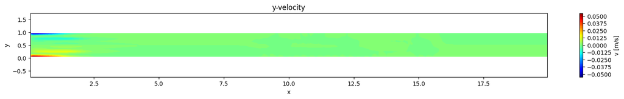

```python
# Check Plots
plt.figure(figsize=(20, 2))
cf = plt.contourf(xcc, ycc, v, levels=50, cmap='jet')
plt.colorbar(cf, label='v [m/s]')
plt.xlabel('x'); plt.ylabel('y')
plt.title('y-velocity')
plt.axis('equal')
plt.show()
```

# Step 7: Construct phiHbyA

Step 7a: interpolating HbyA to faces for interior cells

```python
# central/linear differencing the x-momentum HbyA to four faces
HbyA_x_xf = wx * HbyA_x[:, 1:] + (1-wx) * HbyA_x[:, :-1]
HbyA_x_yf = wy * HbyA_x[1:, :] + (1-wy) * HbyA_x[:-1, :]

# central/linear differencing the y-momentum HbyA to four faces
HbyA_y_xf = wx * HbyA_y[:, 1:] + (1-wx) * HbyA_y[:, :-1]
HbyA_y_yf = wy * HbyA_y[1:, :] + (1-wy) * HbyA_y[:-1, :]

# construct phiHbyA
phiHbyA_x = HbyA_x_xf * Sf_x[:, 1:-1] # + HbyA_y_xf * Sfx_y, but since Sfy_x = 0, so no contribution
phiHbyA_y = HbyA_y_yf * Sf_y[1:-1, :] # + HbyA_x_yf * Sfy_x, but since Sfx_y = 0, so no contribution
```

Step 7b: boundary cells $$A_{p}U - H = -\nabla p$$ so H is the "velocity without pressure" $$H = A_{p}U -(-\nabla p)$$

```python
phiHbyA_x_BC_L = np.full((ny,1), U_in) * Sf_x[:,:1] # velocity inlet at left wall
phiHbyA_x_BC_R = HbyA_x[:, -1:] * Sf_x[:, -1:] # zero gradient at right wall

phiHbyA_y_BC_B = np.zeros((1,nx)) # zero velocity at wall
phiHbyA_y_BC_T = np.zeros((1,nx)) # zero velocity at wall

phiHbyA_x = np.hstack((phiHbyA_x_BC_L, phiHbyA_x, phiHbyA_x_BC_R))
phiHbyA_y = np.vstack((phiHbyA_y_BC_B, phiHbyA_y, phiHbyA_y_BC_T))
```

Step 7c: Rhie-Chow correction

$$U_f = \overline{U_f} - \overline{d_f}\left( \left. \frac{\delta p}{\delta x_j}\right|_{f} - \overline{\left. \frac{\delta p}{\delta x_j}\right|_{f}} \right)$$ where $$d_f = \frac{V_P}{a_P}$$

```python
# computing rAU (reciprocal of the diagonal of the velocity matrix).
rAU_xf = wx * (vol/aP_u)[:, 1:] + (1-wx) * (vol/aP_u)[:, :-1]
rAU_yf = wy * (vol/aP_v)[1:, :] + (1-wy) * (vol/aP_v)[:-1, :]

# interpolated p gradient
grad_p_interp_xf = wx * dpdx[:, 1:] + (1-wx) * dpdx[:, :-1]
# direct differencing p gradient
grad_p_direct_xf = (p[:, 1:] - p[:, :-1]) / dist_x


RC_x = rAU_xf * (grad_p_interp_xf - grad_p_direct_xf) * Sf_x[:, 1:-1]

phiHbyA_x[:, 1:-1] += RC_x


# interpolated p gradient
grad_p_interp_yf = wy * dpdy[1:, :] + (1-wy) * dpdy[:-1, :]
# direct differencing p gradient
grad_p_direct_yf = (p[1:, :] - p[:-1, :]) / dist_y


RC_y = rAU_yf * (grad_p_interp_yf - grad_p_direct_yf) * Sf_y[1:-1, :]

phiHbyA_y[1:-1, :] += RC_y
```

# Step 8: Pressure Equation

$$\nabla \cdot \left(\frac{1}{a_P}\nabla p\right) = \nabla \cdot \left(\frac{H}{A}\right)$$

Step 8a: initialise

```python
aP_p[:,:] = 0
aR_p[:,:] = 0;  aT_p[:,:] = 0;  aL_p[:,:] = 0;  aB_p[:,:] = 0
S_p[:,:] = 0
```

Step 8b: LHS terms $$ \sum_{i=1}^{M} p_{N} \frac{1}{a_{P}} \cdot \frac{S_{i}}{d_{PN}} - p_{P} \sum_{i=1}^{M} \frac{1}{a_{P}} \cdot \frac{S_{i}}{d_{PN}} = \sum_{i=1}^{M} \left( \frac{H}{a_{P}} \right)_{fi} \cdot S_{i} $$ $$LHS = \sum_{i=1}^{M} p_{N} \frac{1}{a_{P}} \cdot \frac{S_{i}}{d_{PN}} - p_{P} \sum_{i=1}^{M} \frac{1}{a_{P}} \cdot \frac{S_{i}}{d_{PN}}$$

```python
# # computing rAU (reciprocal of the diagonal of the velocity matrix). This could be computed from the Rhie-Chow correction step 7c
# rAU_xf = wx * (vol/aP_u)[:, 1:] + (1-wx) * (vol/aP_u)[:, :-1]
# rAU_yf = wy * (vol/aP_v)[1:, :] + (1-wy) * (vol/aP_v)[:-1, :]

# # interior cells
# x-faces
coeff_xf = rAU_xf * Sf_x[:, 1:-1] / dist_x

# L face
aP_p[:, 1:] += coeff_xf
aL_p[:, 1:] += coeff_xf

# R face
aP_p[:, :-1] += coeff_xf
aR_p[:, :-1] += coeff_xf

# y-faces
coeff_yf = rAU_yf * Sf_y[1:-1, :] / dist_y

# B face
aP_p[1:, :] += coeff_yf
aB_p[1:, :] += coeff_yf

# T face
aP_p[:-1, :] += coeff_yf
aT_p[:-1, :] += coeff_yf

# # boundary cells
# left face (velocity inlet with zero pressure gradient)

# Right face (zero gradient pressure outlet), treating the boundary face as a cell
rAU_xf_BC_R = (vol/aP_u)[:, -1:] # using cell value as there is no face value
coeff_xf_BC_R = rAU_xf_BC_R * Sf_x[:, -1:] / (dist_x[:, -1:] / 2)
aP_p[:, -1:] += coeff_xf_BC_R
S_p[:, -1:] += coeff_xf_BC_R * p_out

# bottom face (zero pressure gradient (normal))

# top face (zero pressure gradient (normal))
```

Step 8c: RHS terms $$ \sum_{i=1}^{M} p_{N} \frac{1}{a_{P}} \cdot \frac{S_{i}}{d_{PN}} - p_{P} \sum_{i=1}^{M} \frac{1}{a_{P}} \cdot \frac{S_{i}}{d_{PN}} = \sum_{i=1}^{M} \left( \frac{H}{a_{P}} \right)_{fi} \cdot S_{i} $$ $$RHS = \sum_{i=1}^{M} \left( \frac{H}{a_{P}} \right)_{fi} \cdot S_{i} = phiHbyA$$

```python
# # phiHbyA
# right face
S_p -= phiHbyA_x[:, 1:]
# left face
S_p += phiHbyA_x[:, :-1]
# top face
S_p -= phiHbyA_y[1:, :]
# bottom face
S_p += phiHbyA_y[:-1, :]
```

for pressure under-relaxation

```python
p_old = p.copy()
```

Require fixing presure reference for PISO (TBC)

Step 8d: solve pressure (Gauss-Siedel)

$$ p_{P} \sum_{i=1}^{M} \frac{1}{a_{P}} \cdot \frac{S_{i}}{d_{PN}} = \sum_{i=1}^{M} p_{N} \frac{1}{a_{P}} \cdot \frac{S_{i}}{d_{PN}} - \sum_{i=1}^{M} \left( \frac{H}{a_{P}} \right)_{fi} \cdot S_{i} $$ or $$ p_{P} = \left( \frac{1}{ \sum_{i=1}^{M} \frac{1}{a_{P}}\cdot \frac{S_{i}}{d_{PN}}} \right) \sum_{i=1}^{M} p_{N} \frac{1}{a_{P}} \cdot \frac{S_{i}}{d_{PN}} - \sum_{i=1}^{M} \left( \frac{H}{a_{P}} \right)_{fi} \cdot S_{i} $$ Result: p* (intermediate p)

```python
# # # Option 1: Gauss-Siedel (Very slow, require alternating directions)
# n_inner_iter = 5000

# # # Gauss-Siedel iterate cell by cell using previously updated cell values.
# # # Jocobi precomputes the all neighbour values and update the cell value, hencing using the old cell value.
# for iter in range(n_inner_iter):
#     for i in range(nx):
#         for j in range(ny):
#             p_L = p[j, i-1] if i > 0 else 0.0 # no neighbouring cell on the left
#             p_R = p[j, i+1] if i < nx-1 else 0.0 # no neighbouring cell on the right
#             p_T = p[j+1, i] if j < ny-1 else 0.0 # no neighbouring cell on the top
#             p_B = p[j-1, i] if j > 0 else 0.0 # no neighbouring cell on the bottom

#             p[j, i] = 1/aP_p[j, i] * (aL_p[j, i]*p_L + aR_p[j, i]*p_R + aT_p[j, i]*p_T + aB_p[j, i]*p_B + S_p[j, i])

# # # Option 2: numpy Linear matrix equation (slow)
# N = ny * nx
# A_p = np.zeros((N, N))
# b_p = np.zeros(N)
# for j in range(ny):
#     for i in range(nx):
#         idx = j * nx + i
#         A_p[idx, idx] = aP_p[j, i]
#         b_p[idx] = S_p[j, i]
#         if i > 0:     A_p[idx, idx - 1]  = -aL_p[j, i]
#         if i < nx - 1: A_p[idx, idx + 1]  = -aR_p[j, i]
#         if j < ny - 1: A_p[idx, idx + nx] = -aT_p[j, i]
#         if j > 0:      A_p[idx, idx - nx] = -aB_p[j, i]
# p = np.linalg.solve(A_p, b_p).reshape((ny, nx))


# # # Option 3: Biconjugate gradient stabilised + ILU preconditioner, same as momentum
# p = solve_bicgstab_ilu(aP_p, aL_p, aR_p, aB_p, aT_p, S_p, phi0=p)
```

```python
# # # # Option 4: Conjugate Gradient + Algebraic Multigrid preconditioner
p = solve_pressure_amg(aP_p, aL_p, aR_p, aB_p, aT_p, S_p, p0=np.zeros_like(p))
```

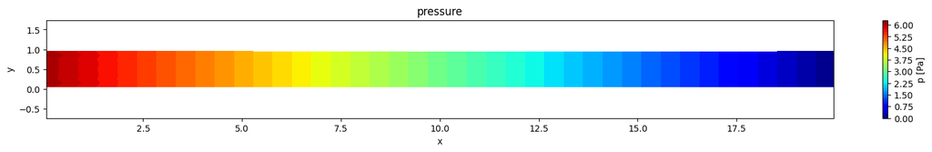

```python
# Check Plots
plt.figure(figsize=(20, 2))
cf = plt.contourf(xcc, ycc, p, levels=50, cmap='jet')
plt.colorbar(cf, label='p [Pa]')
plt.xlabel('x'); plt.ylabel('y')
plt.title('pressure')
plt.axis('equal')
plt.show()
```

# Step 9: Correct velocity, phi (flux), and under-relaxation for pressure

Step 9a-c: update face pressure and update pressure gradient dpdx, dpdy

```python
# Same as Step 2
# Step 9a: linear interp to get face values
p_xf = wx * p[:, 1:] + (1-wx) * p[:, :-1]
p_yf = wy * p[1:, :] + (1-wy) * p[:-1, :]


# Step 9b: apply boundary conditions
p_xBC_L = p[:, :1]                            # zero gradient inlet at left wall
p_xBC_R = np.full((ny, 1), p_out)             # fixed outlet pressure
p_yBC_T = p[-1:, :]                           # zero gradient at top wall
p_yBC_B = p[:1, :]                            # zero gradient at bottom wall

p_xf = np.hstack((p_xBC_L, p_xf, p_xBC_R))
p_yf = np.vstack((p_yBC_B, p_yf, p_yBC_T))

# Step 9c: compute gradients using Green-Gauss theorem
dpdx = (1/vol) * (p_xf[:,1:]*Sf_x[:,1:] - p_xf[:,:-1]*Sf_x[:,:-1]) # Right face - Left face
dpdy = (1/vol) * (p_yf[1:,:]*Sf_y[1:,:] - p_yf[:-1,:]*Sf_y[:-1,:]) # Top face - Bottom face
```

Step 9e: Correct velocities $$U_{p} = \frac{H}{a_{P}} - \frac{V}{a_{P}} \nabla p$$ notice this volume term is generated from the pressure term, as the equation has been discretised in finite volume

```python
u = HbyA_x - (vol/aP_u) * dpdx
v = HbyA_y - (vol/aP_v) * dpdy
```

Step 9f: Correct face fluxes $$F = \sum_{i=1}^{M} S_{i} \cdot U_{f} = \sum_{i=1}^{M} S_{i} \cdot \left[ \left(\frac{H}{A_{P}}\right)_{fi} - \left(\frac{1}{A_{P}}\right)_{fi} \left( \nabla p\right)_{fi} \right] $$

$$ = \sum_{i=1}^{M} \underbrace{S_{i} \cdot \left(\frac{H}{A_{P}}\right)_{fi}}_{\text{phiHbyA}} - \underbrace{ \frac{S_{i}}{d_{PN}} \cdot \left(\frac{1}{A_{P} }\right)_{fi} }_{\text{coeff in pressure step}} \left( p_{N}-p_{P} \right) $$

```python
# # # Correcting flux from the new pressure gradient
# # interior cells
phi_x[:,1:-1] = phiHbyA_x[:,1:-1] - coeff_xf * (p[:,1:] - p[:,:-1])
phi_y[1:-1,:] = phiHbyA_y[1:-1,:] - coeff_yf * (p[1:,:] - p[:-1,:])


# # boundary cells
# left face (velocity inlet)
phi_x[:,0] = U_in * Sf_x[:,0]
# Right face (zero gradient pressure outlet), treating the boundary face as a cell
phi_x[:,-1:] = phiHbyA_x[:,-1:] - coeff_xf_BC_R * (np.full((ny, 1), p_out) - p[:,-1:])

# bottom face (no penetration)
phi_y[0,:] = 0

# top face (no penetration)
phi_y[-1,:] = 0
```

Step 9g: pressure under-relaxation

```python
alpha_p = 0.3       # under-relaxation factor

p = p_old + alpha_p * (p - p_old) # under-relaxation source
```

# Step 10: Solve k-equation

The k transport equation:

$$\nabla \cdot (\mathbf{u}k) = \nabla \cdot \left[\left(\nu + \frac{\nu_t}{\sigma_k}\right)\nabla k\right] + P_k - \epsilon$$

Step 10a: initialise

```python
aP_k[:,:] = 0
aR_k[:,:] = 0;  aT_k[:,:] = 0;  aL_k[:,:] = 0;  aB_k[:,:] = 0
S_k[:,:] = 0
```

Step 10b: convection $$ \sum_{i=1}^M k_{fi}F_{fi}$$

```python
# linear upwind differencing scheme

# interior faces
# # implicit part
# x-faces (interior only: phi_x[:, 1:-1]) (Recomputing F_xf and F_yf after correcting flux)
F_xf = phi_x[:, 1:-1]
F_yf = phi_y[1:-1, :]
# # # L face
aP_k[:, 1:]  += np.maximum(-F_xf, 0)
aL_k[:, 1:]  += np.maximum(F_xf, 0)
# # # R face
aP_k[:, :-1] += np.maximum(F_xf, 0)
aR_k[:, :-1] += np.maximum(-F_xf, 0)
# y-faces (interior only: phi_y[1:-1, :])
# # # B face
aP_k[1:, :]  += np.maximum(-F_yf, 0)
aB_k[1:, :]  += np.maximum(F_yf, 0)
# # # T face
aP_k[:-1, :] += np.maximum(F_yf, 0)
aT_k[:-1, :] += np.maximum(-F_yf, 0)


# Boundary faces
# left boundary (velocity inlet)
F_left = phi_x[:, 0]
# known face value at velocity inlet (accounting for backflow)
S_k[:,0] += np.maximum(F_left, 0) * k_in
aP_k[:,0] += np.maximum(-F_left, 0) # incase backflow

# right boundary (zero gradient)
F_right = phi_x[:, -1]
#  zero gradient: u_face = u_cell, so gradient term = 0
aP_k[:, -1] += np.maximum(F_right, 0) # outflux if F > 0
aP_k[:, -1] += np.maximum(-F_right, 0) # infux if F < 0

# # top boundary (no slip condition)

# # bottom boundary (no slip condition)
```

Step 10c: diffusion implicit

$$ \sum_{i=1}^M \left(\nu + \frac{\nu_t}{\sigma_k}\right)_{fi} \left( \nabla{k} \right)_{fi} \cdot \hat{n_i} A_{i} $$ $$ \sum_{i=1}^M \left(\nu + \frac{\nu_t}{\sigma_k}\right)_{fi} \left( \frac{k_P-k_N}{|d_{PN}|} |\Delta_{fi}|\right) A_{i} $$ For cartesian grid: $$ = k_{P}\sum_{i=1}^M \left(\nu + \frac{\nu_t}{\sigma_k}\right)_{fi} \left( \frac{A_{i}}{|d_{PN}|} \right) - \sum_{i=1}^M k_{N} \left(\nu + \frac{\nu_t}{\sigma_k}\right)_{fi} \left( \frac{A_{i}}{|d_{PN}|} \right)$$

```python
sigma_k = 1.0
# interior cell
Gamma_k = nu + nu_t/sigma_k
Gamma_k_xf = wx * Gamma_k[:, 1:] + (1-wx) * Gamma_k[:, :-1]
Gamma_k_yf = wy * Gamma_k[1:, :] + (1-wy) * Gamma_k[:-1, :]

# Left face calculated velocity inlet
Gamma_k_xf_BC_L = np.full((ny,1), nu + (C_mu * k_in**2 / epsilon_in)/sigma_k)
# Right face zero gradient
Gamma_k_xf_BC_R = Gamma_k[:, -1:]

# # Option 1 Wall function:
# Wall Functions / Zero-Gradient Gamma_k = 0 at the face.
# (And all sublayer viscous destruction is handled via the ϵ source term in the cell).
Gamma_k_yf_BC_B = np.zeros((1, nx))
Gamma_k_yf_BC_T = np.zeros((1, nx))
# # # Option 2 directly resolving sublayers y+<1 (for k-omega SST or those with Low-Re models)
# k=0 at the wall --> Gamma_k = nu
# # nu_t_wall = 0 --> nu_eff_wall = nu
# Gamma_k_yf_BC_B = np.full((1,nx), nu)
# Gamma_k_yf_BC_T = np.full((1,nx), nu)

Gamma_k_xf = np.hstack((Gamma_k_xf_BC_L, Gamma_k_xf, Gamma_k_xf_BC_R))
Gamma_k_yf = np.vstack((Gamma_k_yf_BC_B, Gamma_k_yf, Gamma_k_yf_BC_T))

# Diffusion (implicit):
D_xf = Gamma_k_xf[:, 1:-1] * Sf_x[:, 1:-1] / dist_x                       # ← direct differencing
D_yf = Gamma_k_yf[1:-1, :] * Sf_y[1:-1, :] / dist_y
# (distribute to aP_k and a_nb_k, same pattern as NS momentum)


# x faces
# L face
aP_k[:,1:] += D_xf # +ve LHS term
aL_k[:,1:] += D_xf # +ve after moved to RHS
# R face
aP_k[:,:-1] += D_xf # +ve LHS term
aR_k[:,:-1] += D_xf # +ve after moved to RHS

# y faces
# B face
aP_k[1:,:] += D_yf # +ve LHS term
aB_k[1:,:] += D_yf # +ve after moved to RHS
# T face
aP_k[:-1,:] += D_yf # +ve LHS term
aT_k[:-1,:] += D_yf # +ve after moved to RHS

# boundary cell (treating the boundary face as a cell)
# left face (Dirichlet)
D_xf_BC_L = Gamma_k_xf[:,0] * Sf_x[:,0]/(dist_x[0,0]/2) # special case, distance is half of the cell width, can generalise into dist_x/2
aP_k[:,0] += D_xf_BC_L # +ve LHS term
S_k[:,0] += k_in * D_xf_BC_L # +ve after moved to RHS

# right face (Neumann, zero gradient)

# # bottom face (Wall Function Zero-Gradient (Zero-Flux) condition)

# # top face (Wall Function Zero-Gradient (Zero-Flux) condition)
```

step 10d: dissipation (sink) $$ \epsilon V$$

for wall adjacel cells:

```python
# 1. Re-calculate u* and y* using newly corrected variables (from Step 7)
k_P_B = np.maximum(k[0, :], 1e-10)
k_P_T = np.maximum(k[-1, :], 1e-10)
u_star_B = (C_mu**0.25) * np.sqrt(k_P_B)
u_star_T = (C_mu**0.25) * np.sqrt(k_P_T)
y_star_B = (y_P_B * u_star_B) / nu
y_star_T = (y_P_T * u_star_T) / nu
```

```python
# Overwrite Epsilon in Wall adjacent Cells (epsilonWallFunction)
# BEFORE computing nu_t so that nu_t in the first cell is consistent

# Viscous sublayer exact analytical formulas
eps_visc_B = (2.0 * nu * k_P_B) / (y_P_B**2)
eps_visc_T = (2.0 * nu * k_P_T) / (y_P_T**2)

# Log-law analytical formulas
eps_log_B = (C_mu**0.75 * k_P_B**1.5) / (kappa * y_P_B)
eps_log_T = (C_mu**0.75 * k_P_T**1.5) / (kappa * y_P_T)
```

```python
epsilon[0, :] = np.where(y_star_B > y_cutoff, eps_log_B, eps_visc_B)
epsilon[-1, :] = np.where(y_star_T > y_cutoff, eps_log_T, eps_visc_T)
```

Interior cells:

This term can be explicit or implicit, choose in favour of stability (matrix dominance)

```python
# S_k -= epsilon * vol                 # ← explicit part (if using simple linearization)
# # OR:
aP_k += (epsilon / np.maximum(k, 1e-10)) * vol          # ← implicit: treat as aP_k * k_P (better stability)
```

step 10e: production (source)

$$ P_k V$$ $$ \left[ 2 S_{ij} S_{ij} \nu_{t} \right] V$$ $$\nu_t\left[ (dudx² + dvdy² + \frac{1}{2}*(dudy + dvdx)²)\right] V $$ this production term can be +ve or -ve depending on Pk, if treated implicitly --> can destabilise matrix, so we choose explicit

```python
P_k = nu_t * 2 * (dudx**2 + dvdy**2 + 0.5*(dudy + dvdx)**2)
```

P_k wall function overwrite wall adjacent cells

for wall adjacel cells:

```python
# Overwrite the top and bottom rows with the analytical k-based log-law formula

P_k[0, :] = np.where(y_star_B > y_cutoff, eps_log_B, 0.0)
P_k[-1, :] = np.where(y_star_T > y_cutoff, eps_log_T, 0.0)
```

```python
S_k += P_k * vol
```

step 10f: Under-relaxation $$a_{P}\phi_{P}^n + \frac{1-\alpha}{\alpha}a_{P}\phi_{P}^n + \sum_{i=1}^{M}a_{N}\phi_{N}^n = S_{P} + \frac{1-\alpha}{\alpha}a_{P}\phi_{P}^n$$ $$\frac{a_{P}}{\alpha}\phi_{P}^n + \sum_{i=1}^{M}a_{N}\phi_{N}^n = S_{P} + \frac{1-\alpha}{\alpha}a_{P}\phi_{P}^n$$

```python
alpha_k = 0.5           # under-relaxation factor
k_old = k.copy()

S_k += (1-alpha_k)/alpha_k * aP_k * k_old # under-relaxation source
aP_k = aP_k/alpha_k # inflate diagonal
```

step 10g: Solving k

$$k_{p}=\frac{1}{A_P} \left( \sum_{nb} A_{nb} k_{nb} + S_{k} \right)$$

```python
# # # Option 1: Gauss-Siedel (Very slow, require alternating directions)
# n_inner_iter = 5000

# # # Gauss-Siedel iterate cell by cell using previously updated cell values.
# # # Jocobi precomputes the all neighbour values and update the cell value, hencing using the old cell value.
# for iter in range(n_inner_iter):
#     for i in range(nx):
#         # j_range = range(ny) if iter % 2 == 0 else range(ny - 1, -1, -1)
#         for j in range(ny):
#             k_L = k[j, i-1] if i > 0 else 0.0 # no neighbouring cell on the left
#             k_R = k[j, i+1] if i < nx-1 else 0.0 # no neighbouring cell on the right
#             k_T = k[j+1, i] if j < ny-1 else 0.0 # no neighbouring cell on the top
#             k_B = k[j-1, i] if j > 0 else 0.0 # no neighbouring cell on the bottom

#             k[j, i] = 1/aP_k[j, i] * (aL_k[j, i]*k_L + aR_k[j, i]*k_R + aT_k[j, i]*k_T + aB_k[j, i]*k_B + S_k[j, i])

# # # Option 2: numpy Linear matrix equation (slow)

# N = ny * nx
# A_k = np.zeros((N, N))
# b_k = np.zeros(N)
# for j in range(ny):
#     for i in range(nx):
#         idx = j * nx + i
#         A_k[idx, idx] = aP_k[j, i]
#         b_k[idx] = S_k[j, i]
#         if i > 0:     A_k[idx, idx - 1]  = -aL_k[j, i]
#         if i < nx - 1: A_k[idx, idx + 1]  = -aR_k[j, i]
#         if j < ny - 1: A_k[idx, idx + nx] = -aT_k[j, i]
#         if j > 0:      A_k[idx, idx - nx] = -aB_k[j, i]
# k = np.linalg.solve(A_k, b_k).reshape((ny, nx))
```

```python
# # # Option 3: Biconjugate gradient stabilised + ILU preconditioner
k = solve_bicgstab_ilu(aP_k, aL_k, aR_k, aB_k, aT_k, S_k, phi0=k)
```

step 10h: clipping k

```python
k = np.maximum(k, 1e-10)
```

# Step 11: Solve epsilon-equation

$$\nabla \cdot (\mathbf{u}\epsilon) = \nabla \cdot \left[\left(\nu + \frac{\nu_t}{\sigma_\epsilon}\right)\nabla \epsilon\right] + C_1\frac{\epsilon}{k}P_k - C_2\frac{\epsilon^2}{k}$$

Step 11a: initialise

```python
aP_eps[:,:] = 0
aR_eps[:,:] = 0;  aT_eps[:,:] = 0;  aL_eps[:,:] = 0;  aB_eps[:,:] = 0
S_eps[:,:] = 0
```

Step 11b: convection $$ \sum_{i=1}^M \epsilon_{fi}F_{fi}$$

```python
# linear upwind differencing scheme

# interior faces
# # implicit part
# x-faces (interior only: phi_x[:, 1:-1])
# # # L face
aP_eps[:, 1:]  += np.maximum(-F_xf, 0)
aL_eps[:, 1:]  += np.maximum(F_xf, 0)
# # # R face
aP_eps[:, :-1] += np.maximum(F_xf, 0)
aR_eps[:, :-1] += np.maximum(-F_xf, 0)
# y-faces (interior only: phi_y[1:-1, :])
# # # B face
aP_eps[1:, :]  += np.maximum(-F_yf, 0)
aB_eps[1:, :]  += np.maximum(F_yf, 0)
# # # T face
aP_eps[:-1, :] += np.maximum(F_yf, 0)
aT_eps[:-1, :] += np.maximum(-F_yf, 0)

# Boundary faces
# left boundary (velocity inlet)
F_left = phi_x[:, 0]
# known face value at velocity inlet (accounting for backflow)
S_eps[:,0] += np.maximum(F_left, 0) * epsilon_in
aP_eps[:,0] += np.maximum(-F_left, 0) # incase backflow

# right boundary (zero gradient)
F_right = phi_x[:, -1]
#  zero gradient: u_face = u_cell, so gradient term = 0
aP_eps[:, -1] += np.maximum(F_right, 0) # outflux if F > 0
aP_eps[:, -1] += np.maximum(-F_right, 0) # infux if F < 0

# # top boundary (no slip condition)

# # bottom boundary (no slip condition)
```

Step 11c: diffusion implicit

$$ \sum_{i=1}^M \left(\nu + \frac{\nu_t}{\sigma_{\epsilon}}\right)_{fi} \left( \nabla{\epsilon} \right)_{fi} \cdot \hat{n_i} A_{i} $$ $$ \sum_{i=1}^M \left(\nu + \frac{\nu_t}{\sigma_{\epsilon}}\right)_{fi} \left( \frac{\epsilon_P-\epsilon_N}{|d_{PN}|} |\Delta_{fi}|\right) A_{i} $$ For cartesian grid: $$ = \epsilon_{P}\sum_{i=1}^M \left(\nu + \frac{\nu_t}{\sigma_{\epsilon}}\right)_{fi} \left( \frac{A_{i}}{|d_{PN}|} \right) - \sum_{i=1}^M \epsilon_{N} \left(\nu + \frac{\nu_t}{\sigma_{\epsilon}}\right)_{fi} \left( \frac{A_{i}}{|d_{PN}|} \right)$$

```python
# # same as k-equation
sigma_eps = 1.3
# interior cell
Gamma_eps = nu + nu_t/sigma_eps
Gamma_eps_xf = wx * Gamma_eps[:, 1:] + (1-wx) * Gamma_eps[:, :-1]
Gamma_eps_yf = wy * Gamma_eps[1:, :] + (1-wy) * Gamma_eps[:-1, :]

# Left face calculated velocity inlet
Gamma_eps_xf_BC_L = np.full((ny,1), nu + (C_mu * k_in**2 / epsilon_in)/sigma_eps)
# Right face zero gradient
Gamma_eps_xf_BC_R = Gamma_eps[:, -1:]

# # Option 1 Wall function:
# Wall Functions / Zero-Gradient Gamma_eps = 0 at the face.
# (And all sublayer viscous destruction is handled via the ϵ source term in the cell).
Gamma_eps_yf_BC_B = np.zeros((1, nx))
Gamma_eps_yf_BC_T = np.zeros((1, nx))
# # # Option 2 directly resolving sublayers y+<1 (for k-omega SST or those with Low-Re models)
# k=0 at the wall --> Gamma_eps = nu
# # nu_t_wall = 0 --> nu_eff_wall = nu
# Gamma_eps_yf_BC_B = np.full((1,nx), nu)
# Gamma_eps_yf_BC_T = np.full((1,nx), nu)

Gamma_eps_xf = np.hstack((Gamma_eps_xf_BC_L, Gamma_eps_xf, Gamma_eps_xf_BC_R))
Gamma_eps_yf = np.vstack((Gamma_eps_yf_BC_B, Gamma_eps_yf, Gamma_eps_yf_BC_T))

# Diffusion (implicit):
D_xf = Gamma_eps_xf[:, 1:-1] * Sf_x[:, 1:-1] / dist_x                       # ← direct differencing
D_yf = Gamma_eps_yf[1:-1, :] * Sf_y[1:-1, :] / dist_y
# (distribute to aP_k and a_nb_k, same pattern as NS momentum)

# x faces
# L face
aP_eps[:,1:] += D_xf # +ve LHS term
aL_eps[:,1:] += D_xf # +ve after moved to RHS
# R face
aP_eps[:,:-1] += D_xf # +ve LHS term
aR_eps[:,:-1] += D_xf # +ve after moved to RHS

# y faces
# B face
aP_eps[1:,:] += D_yf # +ve LHS term
aB_eps[1:,:] += D_yf # +ve after moved to RHS
# T face
aP_eps[:-1,:] += D_yf # +ve LHS term
aT_eps[:-1,:] += D_yf # +ve after moved to RHS

# boundary cell (treating the boundary face as a cell)
# left face (Dirichlet)
D_xf_BC_L = Gamma_eps_xf[:,0] * Sf_x[:,0]/(dist_x[0,0]/2) # special case, distance is half of the cell width, can generalise into dist_x/2
aP_eps[:,0] += D_xf_BC_L # +ve LHS term
S_eps[:,0] += epsilon_in * D_xf_BC_L # +ve after moved to RHS
# right face (Neumann, zero-gradient)

# # bottom face (Wall Function Zero-Gradient (Zero-Flux) condition)

# # top face (Wall Function Zero-Gradient (Zero-Flux) condition)(Wall Function Zero-Gradient (Zero-Flux) condition)
```

step 11d: production (source)

$$ C_1\frac{\epsilon}{k}P_k V$$ $$ C_1\frac{\epsilon}{k}\left[ 2 S_{ij} S_{ij} \nu_{t} \right] V$$ $$C_1\frac{\epsilon}{k}\nu_t\left[ (dudx² + dvdy² + \frac{1}{2}*(dudy + dvdx)²)\right] V $$ this production term can be +ve or -ve depending on Pk, if treated implicitly --> can destabilise matrix, so we choose explicit

```python
# # (Optional Clipping for souce and sink term)
# k_safe = np.maximum(k, 1e-10)
# eps_safe = np.maximum(epsilon, 1e-10)

# S_eps += C1 * (eps_safe / k_safe) * P_k * vol
# aP_eps += C2 * (eps_safe / k_safe) * vol
```

```python
C1 = 1.44
# P_k = nu_t * 2 * (dudx**2 + dvdy**2 + 0.5*(dudy + dvdx)**2)

S_eps += C1 * (epsilon/np.maximum(k, 1e-10)) * P_k * vol
```

step 11e: dissipation (sink) $$ C_2\frac{\epsilon^2}{k} V$$ $$ \left( C_2\frac{\epsilon}{k} V \right) \epsilon$$ This term is always +ve, making it implicit improves diagonal dominance

```python
C2 = 1.92

aP_eps += C2 * (epsilon/np.maximum(k, 1e-10)) * vol
```

step 11f: Under-relaxation $$a_{P}\phi_{P}^n + \frac{1-\alpha}{\alpha}a_{P}\phi_{P}^n + \sum_{i=1}^{M}a_{N}\phi_{N}^n = S_{P} + \frac{1-\alpha}{\alpha}a_{P}\phi_{P}^n$$ $$\frac{a_{P}}{\alpha}\phi_{P}^n + \sum_{i=1}^{M}a_{N}\phi_{N}^n = S_{P} + \frac{1-\alpha}{\alpha}a_{P}\phi_{P}^n$$

```python
alpha_eps = 0.5
eps_old = epsilon.copy()

S_eps += (1-alpha_eps)/alpha_eps * aP_eps * eps_old # under-relaxation source
aP_eps = aP_eps/alpha_eps # inflate diagonal
```

step 11g: locking epsilon value at walls

Because we analytically calculated the true value of ϵ at the walls in Step 10 k-equation, we do not want the ϵ matrix solver to change wall values. In OpenFOAM, epsilonWallFunction manipulates the matrix to lock the value.

```python
# In a dense solver, setting the diagonal and source to 1e30 is a safe cheat.
# In a sparse solver with an ILU preconditioner, 1e30 doesn't work
# Bottom wall
aP_eps[0, :] = 1
aB_eps[0, :] = 0.0
aT_eps[0, :] = 0.0
aL_eps[0, :] = 0.0
aR_eps[0, :] = 0.0
S_eps[0, :] = epsilon[0, :] * 1  # epsilon[0,:] already holds the analytical value from Step 8!

# Top wall
aP_eps[-1, :] = 1
aB_eps[-1, :] = 0.0
aT_eps[-1, :] = 0.0
aL_eps[-1, :] = 0.0
aR_eps[-1, :] = 0.0
S_eps[-1, :] = epsilon[-1, :] * 1
```

step 11h: Solving epsilon

$$\epsilon_{p}=\frac{1}{A_P} \left( \sum_{nb} A_{nb} \epsilon_{nb} + S_{\epsilon} \right)$$

```python
# # # Option 1: Gauss-Siedel (Very slow, require alternating directions)
# n_inner_iter = 5000

# # # Gauss-Siedel iterate cell by cell using previously updated cell values.
# # # Jocobi precomputes the all neighbour values and update the cell value, hencing using the old cell value.
# for iter in range(n_inner_iter):
#     for i in range(nx):
#         # j_range = range(ny) if iter % 2 == 0 else range(ny - 1, -1, -1)
#         for j in range(ny):
#             eps_L = epsilon[j, i-1] if i > 0 else 0.0 # no neighbouring cell on the left
#             eps_R = epsilon[j, i+1] if i < nx-1 else 0.0 # no neighbouring cell on the right
#             eps_T = epsilon[j+1, i] if j < ny-1 else 0.0 # no neighbouring cell on the top
#             eps_B = epsilon[j-1, i] if j > 0 else 0.0 # no neighbouring cell on the bottom

#             epsilon[j, i] = 1/aP_eps[j, i] * (aL_eps[j, i]*eps_L + aR_eps[j, i]*eps_R + aT_eps[j, i]*eps_T + aB_eps[j, i]*eps_B + S_eps[j, i])

# # # Option 2: numpy Linear matrix equation (slow)
# N = ny * nx
# A_eps = np.zeros((N, N))
# b_eps = np.zeros(N)
# for j in range(ny):
#     for i in range(nx):
#         idx = j * nx + i
#         A_eps[idx, idx] = aP_eps[j, i]
#         b_eps[idx] = S_eps[j, i]
#         if i > 0:     A_eps[idx, idx - 1]  = -aL_eps[j, i]
#         if i < nx - 1: A_eps[idx, idx + 1]  = -aR_eps[j, i]
#         if j < ny - 1: A_eps[idx, idx + nx] = -aT_eps[j, i]
#         if j > 0:      A_eps[idx, idx - nx] = -aB_eps[j, i]
# epsilon = np.linalg.solve(A_eps, b_eps).reshape((ny, nx))
```

```python
# # # Option 3: Biconjugate gradient stabilised + ILU preconditioner, same as momentum
epsilon = solve_bicgstab_ilu(aP_eps, aL_eps, aR_eps, aB_eps, aT_eps, S_eps, phi0=epsilon)
```

step 11i: clipping epsilon

```python
epsilon = np.maximum(epsilon, 1e-10)
```

# Step 12: Check Convergence

```python
# Pre-compute neighbouring cells
u_L = np.pad(u[:, :-1], ((0,0),(1,0)), constant_values=0) # otherwise 0 because no neighbouring cell on the left
u_R = np.pad(u[:, 1:],  ((0,0),(0,1)), constant_values=0) # otherwise 0 because no neighbouring cell on the right
u_T = np.pad(u[1:, :], ((0,1),(0,0)), constant_values=0) # otherwise 0 because no neighbouring cell on the top
u_B = np.pad(u[:-1, :],  ((1,0),(0,0)), constant_values=0) # otherwise 0 because no neighbouring cell on the bottom

v_L = np.pad(v[:, :-1], ((0,0),(1,0)), constant_values=0)
v_R = np.pad(v[:, 1:],  ((0,0),(0,1)), constant_values=0)
v_T = np.pad(v[1:, :], ((0,1),(0,0)), constant_values=0)
v_B = np.pad(v[:-1, :], ((1,0),(0,0)), constant_values=0)

p_L = np.pad(p[:, :-1], ((0,0),(1,0)), constant_values=0)
p_R = np.pad(p[:, 1:],  ((0,0),(0,1)), constant_values=0)
p_T = np.pad(p[1:, :], ((0,1),(0,0)), constant_values=0)
p_B = np.pad(p[:-1, :], ((1,0),(0,0)), constant_values=0)

k_L = np.pad(k[:, :-1], ((0,0),(1,0)), constant_values=0)
k_R = np.pad(k[:, 1:],  ((0,0),(0,1)), constant_values=0)
k_T = np.pad(k[1:, :], ((0,1),(0,0)), constant_values=0)
k_B = np.pad(k[:-1, :], ((1,0),(0,0)), constant_values=0)

eps_L = np.pad(epsilon[:, :-1], ((0,0),(1,0)), constant_values=0)
eps_R = np.pad(epsilon[:, 1:],  ((0,0),(0,1)), constant_values=0)
eps_T = np.pad(epsilon[1:, :], ((0,1),(0,0)), constant_values=0)
eps_B = np.pad(epsilon[:-1, :], ((1,0),(0,0)), constant_values=0)


# Residuals
R_phi = np.max(np.abs(phi_x[:,1:] - phi_x[:,:-1] + phi_y[1:,:] - phi_y[:-1,:]))
R_u = np.max(np.abs((aP_u*u) - (aL_u*u_L + aR_u*u_R + aT_u*u_T + aB_u*u_B + S_u)))
R_v = np.max(np.abs((aP_v*v) - (aL_v*v_L + aR_v*v_R + aT_v*v_T + aB_v*v_B + S_v)))
R_p = np.max(np.abs((aP_p*p) - (aL_p*p_L + aR_p*p_R + aT_p*p_T + aB_p*p_B + S_p)))
R_k = np.max(np.abs((aP_k*k) - (aL_k*k_L + aR_k*k_R + aT_k*k_T + aB_k*k_B + S_k)))
R_eps = np.max(np.abs((aP_eps*epsilon) - (aL_eps*eps_L + aR_eps*eps_R + aT_eps*eps_T + aB_eps*eps_B + S_eps)))


print(f"iter {iter}: Residuals: phi={R_phi:.4e}, u={R_u:.4e}, v={R_v:.4e}, p={R_p:.4e}, k={R_k:.4e}, eps={R_eps:.4e}")
```

```
iter 1: Residuals: phi=2.6062e-14, u=6.6926e-05, v=1.5256e-04, p=3.0411e-05, k=6.3216e-08, eps=1.9593e-07
```

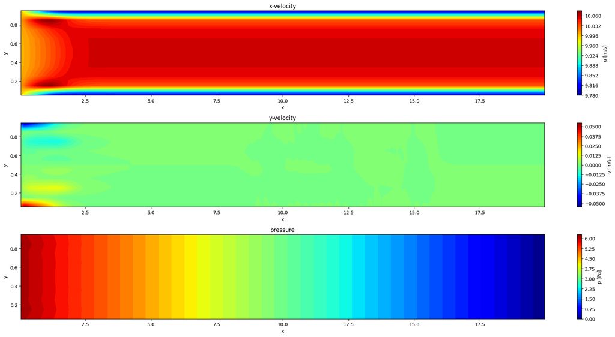

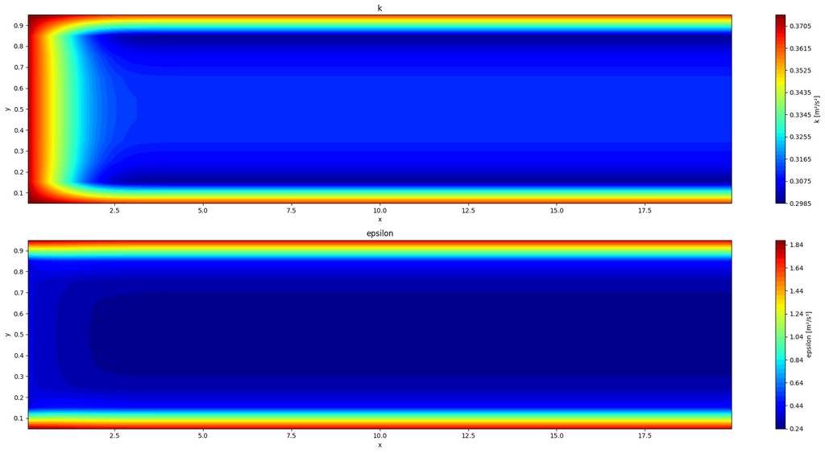

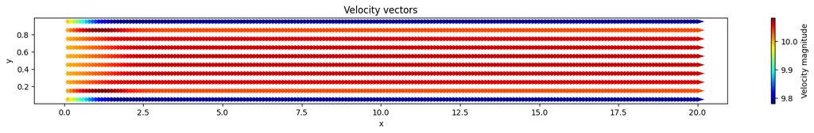

```python
# ---------- Figure 1: Contours ----------
fig1, axes = plt.subplots(3, 1, figsize=(20, 10))

# u
cf1 = axes[0].contourf(xcc, ycc, u, levels=50, cmap='jet')
fig1.colorbar(cf1, ax=axes[0], label='u [m/s]')
axes[0].set_title('x-velocity')
axes[0].set_xlabel('x'); axes[0].set_ylabel('y')

# v
cf2 = axes[1].contourf(xcc, ycc, v, levels=50, cmap='jet')
fig1.colorbar(cf2, ax=axes[1], label='v [m/s]')
axes[1].set_title('y-velocity')
axes[1].set_xlabel('x'); axes[1].set_ylabel('y')

# p
cf3 = axes[2].contourf(xcc, ycc, p, levels=50, cmap='jet')
fig1.colorbar(cf3, ax=axes[2], label='p [Pa]')
axes[2].set_title('pressure')
axes[2].set_xlabel('x'); axes[2].set_ylabel('y')

fig1.tight_layout()

# ---------- Figure 2: Contours ----------
fig1, axes = plt.subplots(2, 1, figsize=(20, 10))

# k
cf4 = axes[0].contourf(xcc, ycc, k, levels=50, cmap='jet')
fig1.colorbar(cf4, ax=axes[0], label='k [m²/s²]')
axes[0].set_title('k')
axes[0].set_xlabel('x'); axes[0].set_ylabel('y')

# epsilon
cf5 = axes[1].contourf(xcc, ycc, epsilon, levels=50, cmap='jet')
fig1.colorbar(cf5, ax=axes[1], label='epsilon [m²/s³]')
axes[1].set_title('epsilon')
axes[1].set_xlabel('x'); axes[1].set_ylabel('y')


fig1.tight_layout()


# ---------- Figure 3: Quiver ----------
fig2, ax2 = plt.subplots(figsize=(20, 2))

M = np.hypot(u, v)
q = ax2.quiver(xcc, ycc, u, v, M, cmap='jet')
fig2.colorbar(q, ax=ax2, label='Velocity magnitude')

ax2.set_title('Velocity vectors')
ax2.set_xlabel('x'); ax2.set_ylabel('y')


# ---------- Show BOTH ----------
plt.show()
```